# Exercise Activity Quality Prediction

Bill Killacky

Saturday, April 25, 2015

### Synopsis

In this report my goal is to predict the **quality** of a particular exercise: a biceps curl.  
The data being used ultimately comes from a human activity study (*Qualitative activity recognition of weight lifting exercises*, 2013).

This report will detail the steps I took to do this prediction. Specifically I’ll detail how I built my predictive model, explain how cross-validation was used, discuss expected out of sample errors, and explain why I made my choices for this analysis.

For another assignment (the Prediction Assignment Submission) we will use the prediction model developed in this report with a new dataset named pml-testing.csv. Of course this new dataset will not have the classe column. It will be our prediction model’s job to identify the proper classe (exercise quality category A to E) to predict 20 test cases.

#### Exercise Quality Classification:

If the biceps curl exercise was done **correctly** it was categorized with an “A”.

- “B” If the elbows were thrown out to the front.
- “C” If the dumbell was lifted only halfway.
- “D” If the dumbell was lowered only halfway.
- “E” If the hips were thrown out to the front.

### How The Model Was Built

The data for this assignment came in the form of a comma-separated-value (pml-training.csv) training file with 19,622 rows and 160 columns. One of the columns contains the ‘classe’ variable we want to learn to predict.  
The prediction study design partitioned the input file into:

- 60% into the training set (11,776 rows)
- 20% into the test set ( 3,923 rows)
- 20% into the validation set ( 3,923 rows)

#### Variable Selection - Preprocessing of the training partition

- The classe variable was converted to a factor variable for each partition set.
- Data columns only having to do with num_window summaries were removed from the training dataset. These included variables beginning with kurtosis, max, min, amplitude, avg, stddev, var, and skewness.
- I also removed rowname, user_name, timestamps, and the new_window variables.
- Training rows with the remaining variables having missing values were excluded.
- Finally all remaining training variables were converted to numeric with the exception of classe.
- As a result I was left with columns including num_window, classe, and the non-summary measures.
- Finally I identified the high correlation variables and removed them since they would add nothing to the prediction process.

### Use of Cross Validation

- Several types of prediction functions were considered, and cross validation allowed an accuracy comparison.
  - The **Random Forest model was best** with 3912 and 3912 correct out of 3923.
  - The generalized Boosted Regression Model had 3844 and 3877 correct out of 3923.
- After selecting Random Forest as the best predictive model for the training set, cross validation approach taken:
  - As mentioned above, the training set was split into **training**, **testing**, and **validating** sets.
  - A predictive model was built using the **training** set.
  - The predictive model was evaluated on the **testing** and the **validating** sets.
  - The average **expected error** of the testing and validating set predictions was calculated as a final output of this cross-validation.

```
##    predictedTesting
##        A    B    C    D    E
##   A 1116    0    0    0    0
##   B    1  757    1    0    0
##   C    0    2  682    0    0
##   D    0    0    5  637    1
##   E    0    0    0    1  720
```

```
## [1] "Prediction on testing dataset is Correct 3912 out of 3923 Accuracy: 99.72 %"
```

```
##    predictedValidating
##        A    B    C    D    E
##   A 1115    1    0    0    0
##   B    1  758    0    0    0
##   C    0    1  682    1    0
##   D    0    0    5  638    0
##   E    0    0    0    2  719
```

```
## [1] "Prediction on validating dataset is Correct 3912 out of 3923 Accuracy: 99.72 %"
```

### Expected Out Of Sample Error

The Random Forest model we created from the training set and it’s Expected Errors on Independent Data (testing, and validating sets):

- After building our model using the training set, two other independent sets were used to calculate the out of sample error.
- The testing set had 11 errors per 3923 or 0.28% Expected Error.
- The validating set had 11 errors per 3923 or 0.28% Expected Error.
- Our Average **Expected Out of Sample Error is therefore 0.28%**.
- Note that while the error rate is the same for the testing and validating sets, the individual predictions differ slightly. (refer to the previous two tables)

### Why I Made My Choices

- We needed to predict if a row of data was best categorized as an A, B, C, D, or E. In other words, we needed a statistical learning method for classification.
- I removed window summary columns that had lots of missing data that could hurt our results.
- I removed columns that had a high correlation to other columns and were therefore not helpful for prediction.
- I chose a study design that provided 60% of the data for creating a prediction model, while allowing for two other datasets to test and validate the prediction model.
- The test and validate sets (which are independent sets from the training set), were used to determine the **out of sample error** and therefore allowed me to choose Random Forest over the Generalized Boosted Regression (gbm) Model because of it’s slightly higher accuracy.

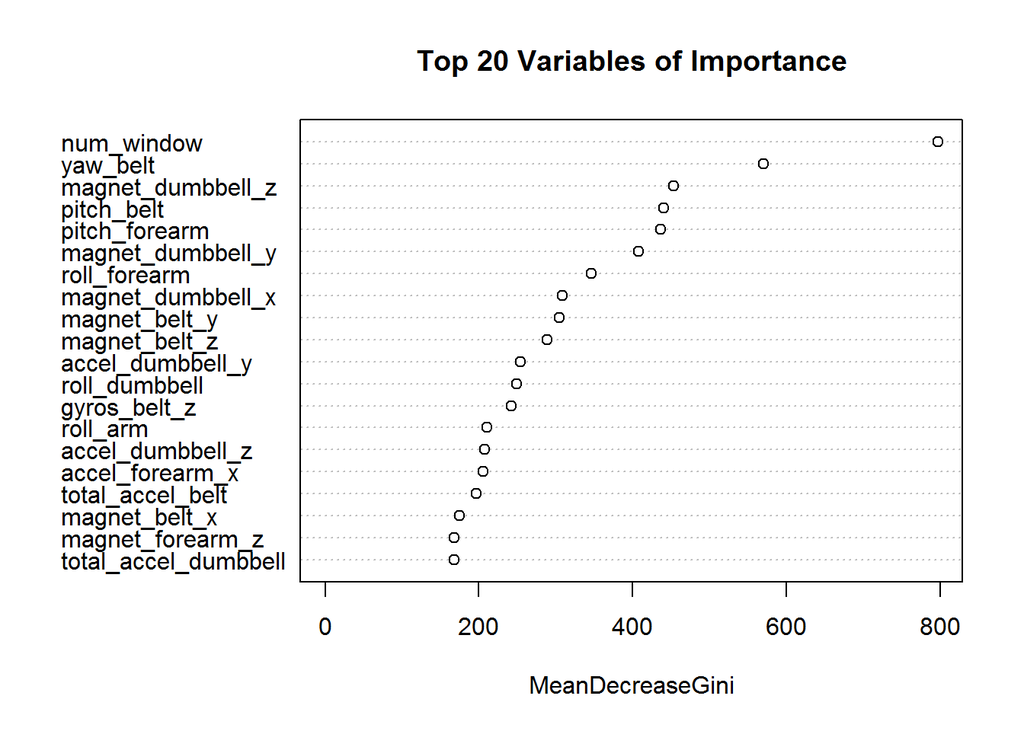

### References

Velloso, E., Bulling, A., Gellersen, H., Ugulino, W., & Fuks, H. (2013). *Qualitative activity recognition of weight lifting exercises*. Retrieved April 25, 2015, from http://groupware.les.inf.puc-rio.br/public/papers/2013.Velloso.QAR-WLE.pdf